# RNA Analysis Pipeline

Wanlu

12 January, 2024

## Dependiencies

- [R](https://cran.rstudio.com)
- [Rstudio](https://posit.co/download/rstudio-desktop/)
- [sratoolkit](https://github.com/ncbi/sra-tools/wiki)
- [conda](https://conda.io/projects/conda/en/latest/user-guide/install/index.html)
- [fastp](https://github.com/OpenGene/fastp#or-compile-from-source)
- [Salmon](https://combine-lab.github.io/salmon/getting_started/)
- [GSEA](https://www.gsea-msigdb.org/gsea/index.jsp)
- [XQuartz](https://www.xquartz.org)

If you are working on an Apple with M2 chip:

- [Xcode](https://developer.apple.com/xcode/)
- [gfortran](https://cran.r-project.org/bin/macosx/tools/)

## 1. Download Raw Fastq File

### 1.1 Download data from GEO

#### 1.1.1 Download and install sratoolkit

For example: I’m working on a Apple silicon M2 Mac. Then I will download the [MacOS Arm64 bit architecture](https://ftp-trace.ncbi.nlm.nih.gov/sra/sdk/3.0.10/sratoolkit.3.0.10-mac-arm64.tar.gz).

```r
## terminal/command shell
cd /Users/wanluchen/Documents/RNA_example_project/tool # where to put sratoolkit
curl https://ftp-trace.ncbi.nlm.nih.gov/sra/sdk/3.0.10/sratoolkit.3.0.10-mac-arm64.tar.gz -o sratoolkit.tar.gz # choose compiled binary that works on your system
tar -vxzf sratoolkit.tar.gz
rm sratoolkit.tar.gz
```

#### 1.1.2 Get metadata

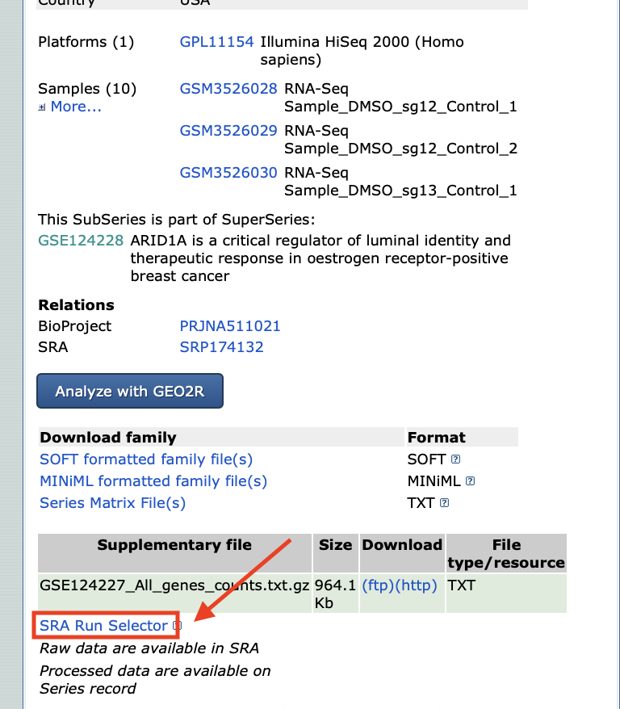

[figure not shown]

Convert **.txt** file to **.csv** file if you want to copy columns from metadata (to make samplesheet later):

```r
#################
## metadata.R  ##
#################

SraRunTable <- read.table(file = "/Users/wanluchen/Documents/RNA_example_project/data/SraRunTable.txt",
                          header = TRUE, sep = ",")
write.csv(SraRunTable, "/Users/wanluchen/Documents/RNA_example_project/data/SraRunTable.csv", row.names = FALSE)
```

#### 1.1.3 Run script

Refer to Appendix if you have lots of samples to download.

**single-end**

```r
## terminal/command shell
bash code/directory/download_data_se.sh [SRR_Acc_Num] [output/directory] [sratoolkit/directory] [number of threads]
```

**paired-end**

```r
## terminal/command shell
bash code/directory/download_data_pe.sh [SRR_Acc_Num] [output/directory] [sratoolkit/directory] [number of threads]
```

**example**

```r
## terminal/command shell
###cd /Volumes/Wanlu/RNA_example_project
bash /Users/wanluchen/Documents/RNA_example_project/code/download_data_pe.sh SRR7629063 /Users/wanluchen/Documents/RNA_example_project/data/raw_fastq /Users/wanluchen/Documents/RNA_example_project/tool/sratoolkit.3.0.10-mac-arm64 4
```

## 2. Remove Adapter (optional)

[A study](https://www.ncbi.nlm.nih.gov/pmc/articles/PMC7671312/) suggested that RNA-seq reads do not need to be trimmed prior to mapping for the purpose of quantifying expression levels of genes. But for other purpose trimming step might be necessary or recommended.

#### 2.1 Download and install fastp

First install [conda](https://conda.io/projects/conda/en/latest/user-guide/install/index.html) into your system.

Then install [fastp](https://github.com/OpenGene/fastp#or-compile-from-source):

```r
## terminal/command shell
conda create -n fastp
conda activate fastp
conda install -c bioconda fastp
conda deactivate
```

*Note that the x86_64 architecture is required for this software. It won’t run or compile on Apple M1/M2 chip.*

#### 2.2 Run script

Refer to Appendix if you have lots of samples to download.

**single-end**

```r
## terminal/command shell
bash code/directory/trim_adapter_se.sh [Read] [SampleName] [input/directory] [output/directory]
```

**paired-end**

```r
## terminal/command shell
bash code/directory/trim_adapter_pe.sh [Read_1] [Read_2] [SampleName] [input/directory] [output/directory]
```

**example**

```r
## terminal/command shell
bash /Users/wanluchen/Documents/RNA_example_project/code/trim_adapter_pe.sh SRR7629063_1.fastq.gz SRR7629063_2.fastq.gz SRR7629063 /Users/wanluchen/Documents/RNA_example_project/data/raw_fastq /Users/wanluchen/Documents/RNA_example_project/data/trim_fastq
```

## 3. Salmon Quantification

#### 3.1 Prepare software and reference genome

Obtain [Salmon](https://combine-lab.github.io/salmon/getting_started/) following the instruction.

Select and download reference genome data [here](http://refgenomes.databio.org). (Unzip the file you will get a folder named **default**. Please change it to the name of genome such as **hg38_salmon_index**.) FYI the pre-built versions of the partial decoy salmon indices for some common organisms:

hg38: [salmon_partial_sa_index:default](http://refgenomes.databio.org/v3/assets/archive/2230c535660fb4774114bfa966a62f823fdb6d21acf138d4/salmon_partial_sa_index?tag=default)

mm10: [salmon_partial_sa_index:default](http://refgenomes.databio.org/v3/assets/archive/0f10d83b1050c08dd53189986f60970b92a315aa7a16a6f1/salmon_partial_sa_index?tag=default)

There are also full decoy versions, which are more accurate but much larger and require more time quantifying.

#### 3.2 Run script

Refer to Appendix if you have lots of samples to download.

**single-end**

```r
## terminal/command shell
bash code/directory/quantification_se.sh [Read] [SampleName] [index/directory] [input/directory] [output/directory] [number of threads]
```

**paired-end**

```r
## terminal/command shell
bash code/directory/quantification_pe.sh [Read_1] [Read_2] [SampleName] [index/directory] [input/directory] [output/directory] [number of threads]
```

**example**

```r
## terminal/command shell
bash /Users/wanluchen/Documents/RNA_example_project/code/quantification_pe.sh SRR7629063_1.fastq.gz SRR7629063_2.fastq.gz SRR7629063 /Users/wanluchen/Documents/RNA_example_project/tool/hg38_salmon_index /Users/wanluchen/Documents/RNA_example_project/data/trim_fastq /Users/wanluchen/Documents/RNA_example_project/data/quants 8
```

## 4. Quality Control

#### 4.1 Prepare R

Download [R](https://cran.rstudio.com). Install [Rstudio](https://posit.co/download/rstudio-desktop/). Open Rstudio and install packages by running the following Rscript. You only need to run it for once.

```r
#########################
## install_packages.R  ##
#########################

# Input Yes if you encounter such question:
# Do you want to attempt to install these from sources? (Yes/no/cancel)

cran.package.list <- c("BiocManager", "glue", "data.table", "magrittr", "rjson",
                       "readxl", "ggplot2", "ggfortify", "ggrepel", "dplyr", "circlize",
                       "magick")

for(package in cran.package.list) {
  tryCatch({
    if(!require(package, character.only = TRUE)) install.packages(package)
    library(package, character.only = T)
  }, error=function(e){cat("ERROR: package", package, "download failed.\n")})
}

bioc.package.list <- c("DESeq2", "ComplexHeatmap", "scater", "GenomicRanges", "limma",
                       "tximeta", "SummarizedExperiment", "biomaRt", "DBI", "GSVA")

for(package in bioc.package.list) {
  tryCatch({
    if(!require(package, character.only = TRUE)) BiocManager::install(package)
    library(package, character.only = T)
  }, error=function(e){cat("ERROR: package", package, "download failed.\n")})
}
```

#### 4.2 Prepare samplesheet

Create a sample sheet in .xlsx with columns: **names**(required) **condition**(required) **quants**(required) …(optional)

- names: sample name (which will be used on figures)
- condition: sample condition
- quants: the name of quant files

**example**

```r
library(readxl)
samplesheet <- read_excel("/Users/wanluchen/Documents/RNA_example_project/data/samplesheet.xlsx")
samplesheet
```

```
## # A tibble: 16 × 3
##    names           condition     quants
##    <chr>           <chr>         <chr>
##  1 KO1_SMARCB1-sg1 sg1_SMARCB1   SRR10425939
##  2 KO2_SMARCB1-sg1 sg1_SMARCB1   SRR10425940
##  3 KO1_SMARCE1-sg1 sg1_SMARCE1   SRR10425941
##  4 KO2_SMARCE1-sg1 sg1_SMARCE1   SRR10425942
##  5 KO1_SMARCB1-sg2 sg2_SMARCB1   SRR10425943
##  6 KO2_SMARCB1-sg2 sg2_SMARCB1   SRR10425944
##  7 KO1_SMARCE1-sg2 sg2_SMARCE1   SRR10425945
##  8 KO2_SMARCE1-sg2 sg2_SMARCE1   SRR10425946
##  9 KO1_SMARCB1-sg3 sg3_SMARCB1   SRR10425947
## 10 KO2_SMARCB1-sg3 sg3_SMARCB1   SRR10425948
## 11 KO1_SMARCE1-sg3 sg3_SMARCE1   SRR10425949
## 12 KO2_SMARCE1-sg3 sg3_SMARCE1   SRR10425950
## 13 GFP1_SMARCB1    sgGFP_Control SRR10425951
## 14 GFP2_SMARCB1    sgGFP_Control SRR10425952
## 15 NT1_SMARCB1     sgNT_Control  SRR10425953
## 16 NT2_SMARCB1     sgNT_Control  SRR10425954
```

#### 4.3 Run script

```r
###############
## get_QC.R  ##
###############

library(glue)
library(data.table)
library(magrittr)
library(rjson)

filename <- dir(path = "/Users/wanluchen/Documents/RNA_example_project/data/quants", full.names = TRUE) ## change path here

mapping_rate_all <- list()
for(i in filename){

  data <- fromJSON(file = glue("{i}/aux_info/meta_info.json"))

  mapping_rate <- data$percent_mapped
  total_read <- data$num_processed
  map_read <- data$num_mapped
  sample_name <- sub(".*/","",i) %>% sub("_quant.*","",.)

  mapping_rate_all[[i]] <- data.frame(quants = sample_name, mapping_rate = mapping_rate,
                                      sequence_read = total_read, map_read = map_read)
}
mapping_rate_combine <- Reduce(rbind,mapping_rate_all)
align_info <- data.frame(mapping_rate_combine)

samplesheet <- read_excel("/Users/wanluchen/Documents/RNA_example_project/data/samplesheet.xlsx")
df <- merge(samplesheet, align_info, by = "quants")

dir.create("/Users/wanluchen/Documents/RNA_example_project/results/QC", showWarnings = FALSE, recursive = TRUE) ## change path here
write.csv(df, file="/Users/wanluchen/Documents/RNA_example_project/results/QC/mapping_rate_rna.csv", row.names = FALSE) ## change path here
```

## 5. Process Data

#### 5.1 Run script

```r
#####################
## process_data.R  ##
#####################

library(data.table)
library(dplyr)
library(GenomicRanges)
library(glue)
library(tximeta)
library(DBI)
library(biomaRt)
library(SummarizedExperiment)

# Metadata ---------------------------------------------------------------------
## change path here
samplesheet <- read_xlsx("/Users/wanluchen/Documents/RNA_example_project/data/samplesheet.xlsx")
samplesheet$files <- paste0("/Users/wanluchen/Documents/RNA_example_project/data/quants/", samplesheet$quants, "_quant/quant.sf")
write.csv(samplesheet, "/Users/wanluchen/Documents/RNA_example_project/data/sample_table.csv", row.names = F)

# Create SummarizedExperiment object -------------------------------------------
coldata <- read.csv("/Users/wanluchen/Documents/RNA_example_project/data/sample_table.csv")

se <- tximeta(coldata)
gse <- summarizeToGene(se)

# annotation -------------------------------------------------------------------
## choose your genome
mart <- useMart('ensembl', dataset = 'hsapiens_gene_ensembl') ## human hg38
# mart <- useMart('ensembl', dataset = 'mmusculus_gene_ensembl',
#                 host = "https://nov2020.archive.ensembl.org") ## mouse mm10
# mart <- useMart('ensembl', dataset = 'mmusculus_gene_ensembl') ## mouse mm39

ens.str <- rownames(gse) <- substr(rownames(gse), 1, 15)
ensemble2gene <- getBM(attributes=c("ensembl_gene_id", "external_gene_name",
                                    "chromosome_name", "start_position", "end_position"),
                       filters = "ensembl_gene_id",
                       values = ens.str,
                       mart = mart)
rownames(ensemble2gene) <- ensemble2gene$ensembl_gene_id

rowData(gse)[rownames(ensemble2gene),"external_gene_name"] <- ensemble2gene$external_gene_name # duplicated with "gene_name"; if no "gene_name", use this
rowData(gse)[rownames(ensemble2gene),"chromosome_name"] <- ensemble2gene$chromosome_name
rowData(gse)[rownames(ensemble2gene),"start_position"] <- ensemble2gene$start_position
rowData(gse)[rownames(ensemble2gene),"end_position"] <- ensemble2gene$end_position

saveRDS(gse, "/Users/wanluchen/Documents/RNA_example_project/data/gse_object.rds")
```

## 6. Exploratory Analysis (PCA)

```r
#################
## plot_PCA.R  ##
#################

library(ggplot2)
library(ggfortify)
library(DESeq2)
library(SummarizedExperiment)

gse <- readRDS("/Users/wanluchen/Documents/RNA_example_project/data/gse_object.rds")
gse$condition <- as.factor(gse$condition)

ddsTxi <- DESeqDataSet(gse, design = ~ condition)
dds <- ddsTxi[rowSums(counts(ddsTxi) >= 10) >= 2,]
vsd <- vst(dds, blind=FALSE)

pcaData <- plotPCA(vsd, intgroup=c("condition"), returnData=TRUE)
percentVar <- round(100 * attr(pcaData, "percentVar"))
p <- ggplot(pcaData, aes(PC1, PC2, color=condition)) +
  geom_point(size=3) +
  xlab(paste0("PC1: ",percentVar[1],"% variance")) +
  ylab(paste0("PC2: ",percentVar[2],"% variance")) +
  coord_fixed() +
  theme(legend.text = element_text(size = 10)) +
  theme(axis.text = element_text(size = 10),
        axis.title = element_text(size = 10)) +
  labs(colour = "Condition")
# save plot in pdf
dir.create("/Users/wanluchen/Documents/RNA_example_project/results/PCA",
           showWarnings = FALSE, recursive = TRUE) ## change path here
pdf("/Users/wanluchen/Documents/RNA_example_project/results/PCA/PCA_group1.pdf",
    width = 5, height = 4) # change path here
p
dev.off()
```

## 7. Differential Analysis

```r
##############################
## differential_analysis.R  ##
##############################

library(GenomicAlignments)
library(data.table)
library(dplyr)
library(DESeq2)
library(GenomicRanges)
library(ggplot2)
library(ggrepel)
library(SummarizedExperiment)
library(glue)


gse <- readRDS("/Users/wanluchen/Documents/RNA_example_project/data/gse_object.rds")

## if you want to change conditions, you can do it here
## for example
## gse$condition <- gsub("sg.*_","",gse$condition)

gse$condition <- as.factor(gse$condition)
ddsTxi <- DESeqDataSet(gse, design = ~ condition)
dds <- ddsTxi[rowSums(counts(ddsTxi) >= 10) >= 2,]
dds <- DESeq(dds)


## run this section if you need GSEA later
if(1) {
  # generate expression file
  normalized_counts <- counts(dds, normalized = T)
  exp.dat <- data.frame(NAME = rowData(dds)$gene_name, DESCRIPTION = "NA")
  exp.dat <- cbind(exp.dat, normalized_counts)
  exp.dat <- exp.dat[order(exp.dat$NAME),]
  dir.create("/Users/wanluchen/Documents/RNA_example_project/results/gsea/input",
             showWarnings = FALSE, recursive = TRUE) ## change path here
  write.table(exp.dat, file = "/Users/wanluchen/Documents/RNA_example_project/results/gsea/input/expression.txt",
              sep = "\t", row.names = FALSE, quote = FALSE) ## change path here

  # n(samples) n(classes) 1
  # UserVisibleName_1 ... UserVisibleName_n(classes), (the order matches the unique names from the 3rd line)
  # Name_1 ... Name_n(samples), (classification for each sample)
  colnames(exp.dat)
  pheno <- rbind(paste(c(ncol(dds), length(unique(dds$condition)), 1), collapse = " "), ## change numbers here
                 paste0("# ", paste(unique(dds$condition), collapse = " ")), ## change names here
                 paste(dds$condition, collapse = " "))
  write.table(pheno, file = "/Users/wanluchen/Documents/RNA_example_project/results/gsea/input/ph.cls",
              sep = "\n", row.names = FALSE, col.names = FALSE, quote = FALSE) ## change path here
}


# differential analysis
# Mutant vs Control
res <- results(dds, contrast=c("condition", "sg1_SMARCB1", "sgNT_Control"))
dir.create("/Users/wanluchen/Documents/RNA_example_project/results/differential_analysis/",
           showWarnings = FALSE, recursive = TRUE) ## change path here


# check the number of differential genes
## change threshold here
resOrdered <- res[order(res$padj),]
# significant: genes with adjusted p-value < 0.05 and log2 Fold Change > 0 or log2 Fold Change < 0
length(which(resOrdered$padj < 0.05 & abs(resOrdered$log2FoldChange) > 0))
# up-regulated: genes with adjusted p-value < 0.05 and log2 Fold Change > 0
(n.up <- length(which(resOrdered$padj < 0.05 & resOrdered$log2FoldChange > 0)))
# down-regulated: genes with adjusted p-value < 0.05 and log2 Fold Change < 0
(n.down <- length(which(resOrdered$padj < 0.05 & resOrdered$log2FoldChange < 0)))


# Volcano plot
resOrdered <- data.frame(resOrdered)
de <- resOrdered[complete.cases(resOrdered), ] ## !!! NOTE: customize filtering here !!!
de$diffexpressed <- "Not Significant"
de$diffexpressed[de$log2FoldChange > 0 & de$padj < 0.05] <- glue("Up (n={n.up})")
de$diffexpressed[de$log2FoldChange < 0 & de$padj < 0.05] <- glue("Down (n={n.down})")
de$delabel <- NA
p <- ggplot(data=de, aes(x=log2FoldChange, y=-log10(padj), col=diffexpressed, label=delabel)) +
  geom_point(alpha = 0.4) +
  theme_bw() +
  scale_color_manual(values=c("blue", "black", "red")) +
  theme(legend.text = element_text(size = 10)) +
  theme(axis.text = element_text(size = 10),
        axis.title = element_text(size = 10)) +
  labs(colour = "")
p
# save plot in pdf
pdf("/Users/wanluchen/Documents/RNA_example_project/results/differential_analysis/VolcanoPlot_pval0.05.pdf",
    width = 5, height = 4) ## change path here
p
dev.off()


# save results
resOrdered <- cbind(resOrdered, rowData(gse)[rownames(resOrdered),])
normalized_counts <- counts(dds, normalized = T) ## if you want normalized count, run this; otherwise skip
resOrdered <- cbind(resOrdered, normalized_counts[rownames(resOrdered),]) ## if you want normalized count, run this; otherwise skip
resOrdered <- apply(resOrdered,2,as.character)
write.csv(resOrdered, file = "/Users/wanluchen/Documents/RNA_example_project/results/differential_analysis/diffRes_sg1SMARCB1_sgNTControl.csv") ## change path here
```